# Demonstrating Lindley’s Paradox

Jacob L. Fine

April 27th, 2024

An apparent paradox emerges when applying both the Bayesian and Frequentist approaches to hypothesis testing, where under certain conditions, we would reject $H_0$ when using a Frequentist approach but not under a Bayesian approach. Here, I will demonstrate cases where the p-value, $P(x|H_0)$ is small but the posterior probability that the null hypothesis is true given the data, $P(H_0|x)$, is large. The latter is used in Bayesian hypothesis testing to compute the posterior odds, $Odds = P(H_1|x)/P(H_0|x)$ which if sufficiently larger, entails us to reject $H_0$.

Showing the relationship between the p-value, which is equivalent to $P(x|H_0)$ and the $P(H_0|x)$, we use Bayes’ theorem:

$$P(H_0|x) = \frac{P(x|H_0)P(H_0)}{P(x)}$$

We then use the law of total probability, using the weightings $P(H_1)$ and $P(H_0)$, to obtain that

$$P(x) = P(x|H_0)P(H_0) +
P(x|H_1)P(H_1)$$

$$\implies P(H_0|x) =
\frac{P(x|H_0)P(H_0)}{P(x|H_0)P(H_0) + P(x|H_1)P(H_1)}$$

Suppose we are modelling counts of the number of transcription start sites per gene and postulate that our data come from a Poisson distribution with an expected value of $\lambda = 4$ counts per gene under the null hypothesis. We therefore have, using the probability mass function (pmf) of the Poisson distribution:

$$P(x|H_0) = \frac{e^{-4} 4^x}{x!}$$

$$\implies P(H_0|x) = \frac{\frac{e^{-4}
4^x}{x!}P(H_0)}{\frac{e^{-4} 4^x}{x!}P(H_0) + P(x|H_1)P(H_1)}$$

To deal with the term $ P(x|H_1)$, let us assume that $\lambda$ follows a normal distribution $N(0,1)$. The probability we are interested in can be expressed as

$$P(x|H_1) = f(x) =
\int_{-\infty}^{\infty}f(x,\lambda)d\lambda$$
$$\implies f(x) =
\int_{-\infty}^{\infty}f(x|\lambda)f(\lambda)d\lambda$$

But our pmf is not defined for negative values, so we can write

$$\implies f(x) = \int_{0}^{\infty}
\frac{e^{-\lambda} \lambda^x}{x!} \cdot \frac{1}{\sqrt{2\pi}}
e^{-\frac{\lambda^2}{2}}d\lambda = P(x|H_1)$$
This integral does not have a closed form but we can solve it numerically in R. Substituting this into our result from Bayes’ theorem, we have

$$\implies P(H_0|x) = \frac{\frac{e^{-4}
4^x}{x!}P(H_0)}{\frac{e^{-4} 4^x}{x!}P(H_0) + ( \int_{0}^{\infty}
\frac{e^{-\lambda} \lambda^x}{x!} \cdot \frac{1}{\sqrt{2\pi}}
e^{-\frac{\lambda^2}{2}}d\lambda)P(H_1)}$$

We may now wish to evaluate $P(H_0|x)$ and $P(H_1|x)$ at different values of $x$, and for different choices of priors. We want to show that $P(H_0|x)$ can be large while $P(x|H_0)$ is small, leading to an apparent contradiction in when the null hypothesis is rejected.

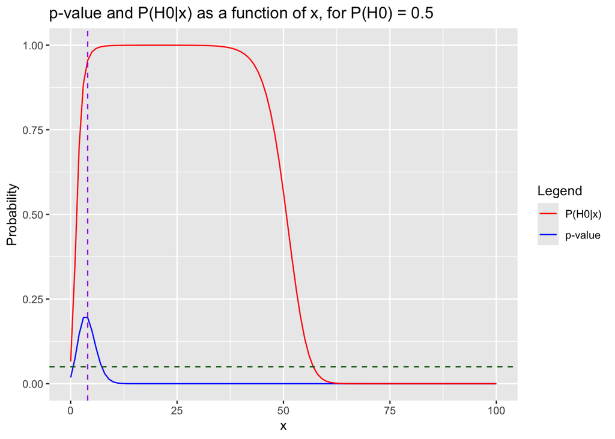

```r
# import ggplot
library(ggplot2)

# a function to compute the probabilities of interest for a specific value of P_H0
compute_probabilities_single <- function(x_values, P_H0) {
  # since H0 and H1 are two complementary events so we can use pA = 1 - pB
  P_H1 <- 1 - P_H0

  # we now initialize an empty dataframe to store results
  results_df <- data.frame(
    x = numeric(length(x_values)),
    P_x_H0 = numeric(length(x_values)),
    P_H0_given_x = numeric(length(x_values)),
    P_H0 = P_H0,  # Add P_H0 and P_H1 directly to the dataframe
    P_H1 = P_H1,
    posterior_odds = numeric(length(x_values))
  )

  # for each value of x, we calculate the probabilities
  for (i in seq_along(x_values)) {
    # selects value of x
    x <- x_values[i]
    # adds current values of x, P_x_H0, and P_H0_x to dataframe
    results_df[i, "x"] <- x
    # computes the p-value
    results_df[i, "P_x_H0"] <- exp(-4) * (4^x) / factorial(x)
    # computes P(H0_given_x)
    numerator <- results_df[i, "P_x_H0"] * P_H0
    # finds the integral numerically
    denominator <- numerator + integrate(function(lambda) (exp(-lambda) * (lambda^x) / factorial(x) * (1 / sqrt(2 * pi)) * exp(-(lambda^2) / 2)), 0, Inf)$value * P_H1
    results_df[i, "P_H0_given_x"] <- numerator / denominator

    # computes the posterior odds
    results_df[i, "posterior_odds"] <- (1 - results_df[i, "P_H0_given_x"]) / results_df[i, "P_H0_given_x"]
  }

  return(results_df)
}

# generates a list of input values x
x_values <- seq(0, 100)

# specify the values of P(H0) you want to use
P_H0_values <- c(0.5, 0.7, 0.9)

# initialize a list to store plots
plot_list <- list()

# loop through each value of P(H0) and generate plots
for (P_H0 in P_H0_values) {
  # compute probabilities for the specified P_H0
  plot_df <- compute_probabilities_single(x_values, P_H0)

  # Plot P(x | H0) and P(H0 | x) versus x
  p <- ggplot(plot_df, aes(x = x)) +
    geom_line(aes(y = P_x_H0, color = "P(x | H0)")) +
    geom_line(aes(y = P_H0_given_x, color = "P(H0 | x)")) +
    geom_vline(xintercept = 4, linetype = "dashed", color = "purple") +  # Add vertical line at x = 4
    geom_hline(yintercept = 0.05, linetype = "dashed", color = "darkgreen") +  # Add horizontal line at y = 0.05
    labs(x = "x", y = "Probability", color = "Legend") +
    ggtitle(paste0("p-value and P(H0|x) as a function of x, for P(H0) = ", P_H0, "")) +
    scale_color_manual(
      values = c("P(x | H0)" = "blue", "P(H0 | x)" = "red"),
      labels = c("P(x | H0)" = "p-value", "P(H0 | x)" = "P(H0|x)", "purple" = "x = 4", "darkgreen" = "y = 0.05")
    )

  # Add the plot to the plot list
  plot_list[[as.character(P_H0)]] <- p
}

# Print the plots
print(plot_list$`0.5`)
```

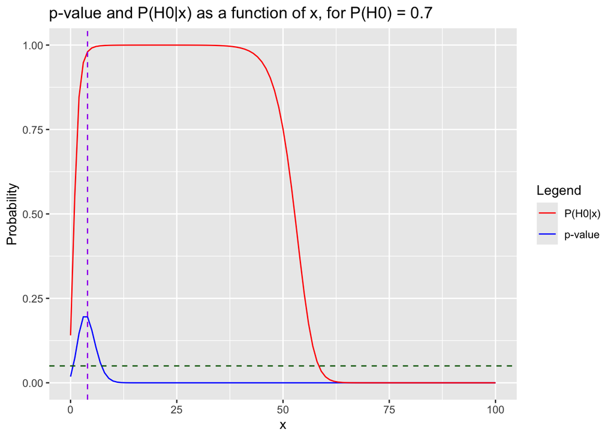

```r
print(plot_list$`0.7`)
```

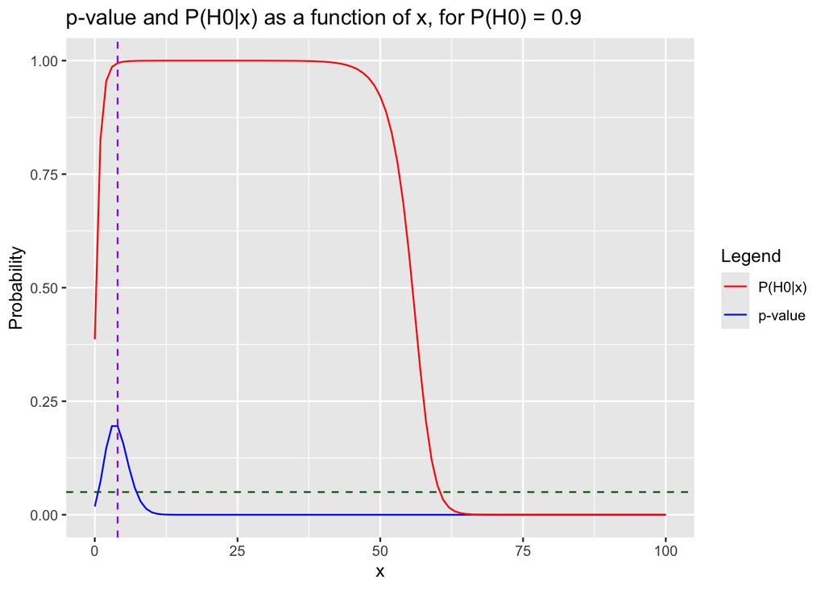

```r
print(plot_list$`0.9`)
```

In the above, the vertical purple dotted line marks the value $x=4$ which is the value of the null $\lambda$, which corresponds to the largest (and therefore most statistically insignificant) p-value. We can observe the paradox in effect when we see large values of $P(H_0|x)$ occuring in cases were the p-value is below 0.05, indicated by the horizontal green dotted line.